# Homework 3

your name here

19 October, 2023

**Due October 16, 2023 prior to 1:30 PM.**

**You may discuss the homework problems and computing issues with other students in the class and submit questions to the Canvas discussion board. However, you must write up your homework solution on your own. In particular, do not share your R files with other students. Please list the students you worked with below:**

Students worked with: XXXXX

Lectures: Module 3 (parts I, II, and III)

Objectives:

1. Fit and interpret a Poisson model.
2. Understand offsets.
3. Perform diagnostics in a Poisson model.
4. Fit and interpret a logistic mixed model with multiple variance components.

# 1 Problem 1.

The dataset contains the number of HIV cases at the state level in 2016. The data were obtained from https://www.cdc.gov/nchhstp/atlas.

**1.** Run the code below to create a dataset. Then fit the intercept only model with response variable `Cases` using ordinary least squares and the R function `lm()`. Interpret the intercept.

```r
hiv_cases = read.csv('AtlasPlusTableData_HIV_2016.csv')
socdet = read.csv('AtlasPlusTableData_SocialDeterminants_2016.csv')

library(tidyr)
socdet_wide = socdet%>%pivot_wider(names_from = Indicator, values_from=Percent)

dat = merge(hiv_cases,socdet_wide)
dat$Pop100k = dat$Cases/dat$Rate.per.100000
```

```r
model0 = lm(dat$Cases~1)
summary(model0)
```

```
##
## Call:
## lm(formula = dat$Cases ~ 1)
##
## Residuals:
##    Min     1Q Median     3Q    Max
## -768.1 -679.1 -422.1   51.9 4293.9
##
## Coefficients:
##             Estimate Std. Error t value Pr(>|t|)
## (Intercept)    773.1      162.9   4.744 1.79e-05 ***
## ---
## Signif. codes:  0 '***' 0.001 '**' 0.01 '*' 0.05 '.' 0.1 ' ' 1
##
## Residual standard error: 1164 on 50 degrees of freedom
```

The average number of cases per state is 773.

**2.** Next, fit an intercept-only Poisson model to `Cases` and interpret the intercept on the log-scale and back-transformed scale.

```r
model1 = glm(Cases~1,data=dat,family=poisson)
summary(model1)
```

```
##
## Call:
## glm(formula = Cases ~ 1, family = poisson, data = dat)
##
## Deviance Residuals:
##     Min       1Q   Median       3Q      Max
## -38.545  -31.045  -17.025    1.803  102.300
##
## Coefficients:
##             Estimate Std. Error z value Pr(>|z|)
## (Intercept) 6.650381   0.005036    1321   <2e-16 ***
## ---
## Signif. codes:  0 '***' 0.001 '**' 0.01 '*' 0.05 '.' 0.1 ' ' 1
##
## (Dispersion parameter for poisson family taken to be 1)
##
##     Null deviance: 59026  on 50  degrees of freedom
## Residual deviance: 59026  on 50  degrees of freedom
## AIC: 59412
##
## Number of Fisher Scoring iterations: 6
```

The log rate of cases per state is 6.65. There are approximately $e^{6.65}=773$ cases per state.

**3.** What is $\widehat{Var}(y_i)$ in the lm? What is $\widehat{Var}(y_i)$ in the Poisson model?

$\widehat{Var}(y_i)$ in the lm is the residual standard error squared, i.e., $1164^2 \approx 1354896$. Similarly, $\hat{\sigma}^2 = \frac{\sum_{i=1}^{N}(y_i-\bar{y})^2}{N-1} = 1354169$.

$Var(Y_i) = \lambda_i$ in the Poisson model. Here, $\hat\lambda_i = e^{6.650381}$ = 773.0788.

**4.** Next, fit an intercept only quasipoisson model to Cases. According to this model, what is the expected counts, and how does this compare to 1.2?

```r
model2 = glm(Cases~1,data=dat,family=quasipoisson)
summary(model2)
```

```
##
## Call:
## glm(formula = Cases ~ 1, family = quasipoisson, data = dat)
##
## Deviance Residuals:
##     Min       1Q   Median       3Q      Max
## -38.545  -31.045  -17.025    1.803  102.300
##
## Coefficients:
##             Estimate Std. Error t value Pr(>|t|)
## (Intercept)   6.6504     0.2108   31.55   <2e-16 ***
## ---
## Signif. codes:  0 '***' 0.001 '**' 0.01 '*' 0.05 '.' 0.1 ' ' 1
##
## (Dispersion parameter for quasipoisson family taken to be 1751.658)
##
##     Null deviance: 59026  on 50  degrees of freedom
## Residual deviance: 59026  on 50  degrees of freedom
## AIC: NA
##
## Number of Fisher Scoring iterations: 6
```

The expected count is $e^{6.65}=773$, which is the same as the result of 1.2.

**5.** What is the dispersion parameter? Are there issues with the original Poisson model?

The dispersion parameter is 1751.658, which is much greater than 1. This means the original Poisson model assumption with respect to variance is not satisfied.

**6.** Now fit an intercept-only OLS model to log `Rate.per.100000`. Interpret the intercept on the log-scale and back-transformed scale.

```r
model3 = lm(log(Rate.per.100000)~1,data=dat)
summary(model3)
```

```
##
## Call:
## lm(formula = log(Rate.per.100000) ~ 1, data = dat)
##
## Residuals:
##      Min       1Q   Median       3Q      Max
## -2.34168 -0.42803 -0.02805  0.51726  1.84965
##
## Coefficients:
##             Estimate Std. Error t value Pr(>|t|)
## (Intercept)   2.2363     0.1007   22.21   <2e-16 ***
## ---
## Signif. codes:  0 '***' 0.001 '**' 0.01 '*' 0.05 '.' 0.1 ' ' 1
##
## Residual standard error: 0.719 on 50 degrees of freedom
```

The expected number of the log of cases per 100,000 people is 2.24, or approximately $e^{2.24}=9.4$ cases per 100,000 people. The back-transformed value is the exponentiated average log rate ($\exp(\frac{1}{n}\sum \log y_i)$).

**7.** Next, fit a Poisson model with offset log `Pop100k`. Interpret the intercept on the log-scale and back-transformed scale.

```r
dat$logPop100k = log(dat$Pop100k)
model4 = glm(Cases~offset(logPop100k),data=dat,family=poisson)
summary(model4)
```

```
##
## Call:
## glm(formula = Cases ~ offset(logPop100k), family = poisson, data = dat)
##
## Deviance Residuals:
##     Min       1Q   Median       3Q      Max
## -21.111  -11.950   -7.357    2.600   36.769
##
## Coefficients:
##             Estimate Std. Error z value Pr(>|z|)
## (Intercept) 2.681086   0.005036   532.4   <2e-16 ***
## ---
## Signif. codes:  0 '***' 0.001 '**' 0.01 '*' 0.05 '.' 0.1 ' ' 1
##
## (Dispersion parameter for poisson family taken to be 1)
##
##     Null deviance: 8266.7  on 50  degrees of freedom
## Residual deviance: 8266.7  on 50  degrees of freedom
## AIC: 8653.3
##
## Number of Fisher Scoring iterations: 4
```

```r
exp(2.681086)
```

```
## [1] 14.60094
```

The log of the expected number of cases per 100,000 people is 2.68. The rate is approximately $e^{2.68}=14.6$ cases per 100,000 people.

**8.** Jensen’s inequality states that for a concave function $f(.)$, we have
$$E(f(X))\leq f(E(X)).$$
. How should the coefficient in the lm of the log rate compare to the coefficient in the Poisson model?

In our case, $f(X) = log(X)$, which is a concave function. The coefficient in the lm of the log rate is $E(log(y_i/pop_i))$ which is smaller than the coefficient in the Poisson model $log(E(y_i/pop_i))$.

**9.** Next, write out the Poisson model fitting `Cases` with the offset log `Pop100k` and the centered predictors `Households living below the federal poverty level`, `Population 25 years and older w/o HS diploma`, `Uninsured`, and `Vacant housing`. (In writing out this model, indicate that the predictors are centered in your description of the predictors. The offset is not centered.)

Assume
$$y_{i} \overset{ind}{\sim}
Poisson(\lambda_{i}),$$
$$\log(\lambda_{i}) = \log (Pop100k) +
\beta_0+\beta_1x_{i1}+\beta_2x_{i2}+\beta_3x_{i3}+\beta_4x_{i4},$$
where $Pop100k$ is the population in hundred thousands, $x_{i1}$ = centered households living below the federal poverty level, $x_{i2}$ = centered population 25 years and older w/o HS diploma, $x_{i3}$= centered uninsured and $x_{i4}$ = centered vacant housing, $\beta_0$ = intercept, $\beta_k, k = 1 \cdots 4$ are coefficients for $x_{ik}, k = 1 \cdots 4$.

**10.** Fit this model. Are the coefficients significant according to the output of `summary()`?

```r
dat$c_households = scale(dat$`Households living below the federal poverty level`,scale = FALSE)
dat$c_nohs = scale(dat$`Population 25 years and older w/o HS diploma`,scale = FALSE)
dat$c_uninsured = scale(dat$Uninsured,scale = FALSE)
dat$c_vacant = scale(dat$`Vacant housing`,scale=FALSE)

model5 = glm(Cases~c_households+c_nohs+c_uninsured+c_vacant,offset = log(Pop100k), data=dat,family=poisson)

summary(model5)
```

```
##
## Call:
## glm(formula = Cases ~ c_households + c_nohs + c_uninsured + c_vacant,
##     family = poisson, data = dat, offset = log(Pop100k))
##
## Deviance Residuals:
##     Min       1Q   Median       3Q      Max
## -14.475   -8.308   -4.748    0.446   26.364
##
## Coefficients:
##              Estimate Std. Error z value Pr(>|z|)
## (Intercept)  2.550404   0.006454 395.143   <2e-16 ***
## c_households 0.004750   0.004087   1.162    0.245
## c_nohs       0.062394   0.003082  20.241   <2e-16 ***
## c_uninsured  0.033650   0.001724  19.518   <2e-16 ***
## c_vacant     0.029631   0.002100  14.108   <2e-16 ***
## ---
## Signif. codes:  0 '***' 0.001 '**' 0.01 '*' 0.05 '.' 0.1 ' ' 1
##
## (Dispersion parameter for poisson family taken to be 1)
##
##     Null deviance: 8266.7  on 50  degrees of freedom
## Residual deviance: 4786.4  on 46  degrees of freedom
## AIC: 5181
##
## Number of Fisher Scoring iterations: 4
```

According to the results above, coefficients of `Population 25 years and older w/o HS diploma`, `Uninsured`, and `Vacant housing` are significant with p-value<2e-16. Coefficient of `Households living below the federal poverty level` is not significant.

**11.** Conduct a goodness of fit test. State the Null hypothesis and your conclusion.

```r
# goodness of fit test:
with(model5, cbind(res.deviance = deviance, df = df.residual, p = pchisq(deviance, df.residual, lower.tail=FALSE)))
```

```
##      res.deviance df p
## [1,]     4786.386 46 0
```

```r
# another possible test for overdispersion:
library(AER)
dispersiontest(model5)
```

```
##
##  Overdispersion test
##
## data:  model5
## z = 3.1164, p-value = 0.0009153
## alternative hypothesis: true dispersion is greater than 1
## sample estimates:
## dispersion
##   109.8458
```

```r
# I prefer the goodness of it. This dispersiontest should be highly significant, since the dispersion parameter is HUGE
```

H0: The model adequately fits the data. (Other possibilities: The model is correctly specified. There is no lack of fit.)

According to the GOF test, with p-value = 0, we reject H0 and conclude there is a lack of fit.

**12.** Are the p-values from the model valid? If invalid, state why they are invalid.

The p-values are invalid since the model doesn’t adequately fit the data.

**13.** Fit the Poisson model with overdispersion parameter. What is the overdispersion parameter, and what would it be equal to if model assumptions were met?

```r
model6 = glm(Cases~c_households+c_nohs+c_uninsured+c_vacant, offset = log(Pop100k), data=dat,family=quasipoisson)

summary(model6)
```

```
##
## Call:
## glm(formula = Cases ~ c_households + c_nohs + c_uninsured + c_vacant,
##     family = quasipoisson, data = dat, offset = log(Pop100k))
##
## Deviance Residuals:
##     Min       1Q   Median       3Q      Max
## -14.475   -8.308   -4.748    0.446   26.364
##
## Coefficients:
##              Estimate Std. Error t value Pr(>|t|)
## (Intercept)   2.55040    0.07120  35.820   <2e-16 ***
## c_households  0.00475    0.04508   0.105   0.9165
## c_nohs        0.06239    0.03400   1.835   0.0730 .
## c_uninsured   0.03365    0.01902   1.769   0.0835 .
## c_vacant      0.02963    0.02317   1.279   0.2074
## ---
## Signif. codes:  0 '***' 0.001 '**' 0.01 '*' 0.05 '.' 0.1 ' ' 1
##
## (Dispersion parameter for quasipoisson family taken to be 121.6911)
##
##     Null deviance: 8266.7  on 50  degrees of freedom
## Residual deviance: 4786.4  on 46  degrees of freedom
## AIC: NA
##
## Number of Fisher Scoring iterations: 4
```

The overdispersion parameter is 121.6911. It should be 1 if model assumptions were met.

**14.** Create the diagnostic plots from `plot()` and comment on whether model assumptions are met.

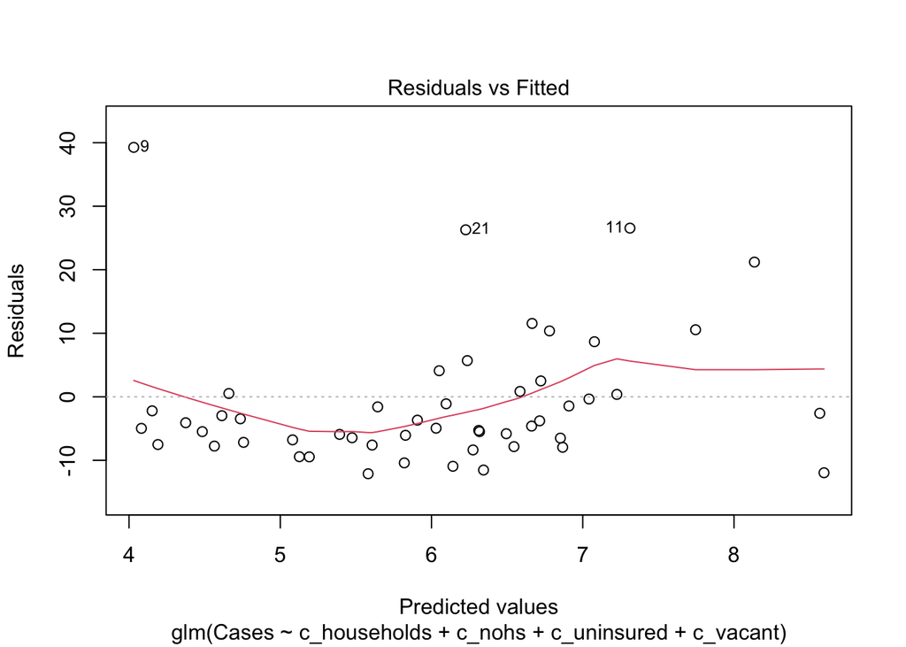

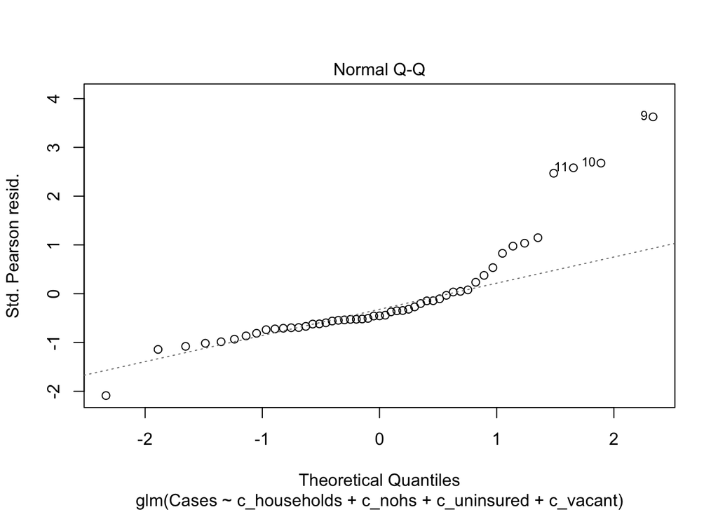

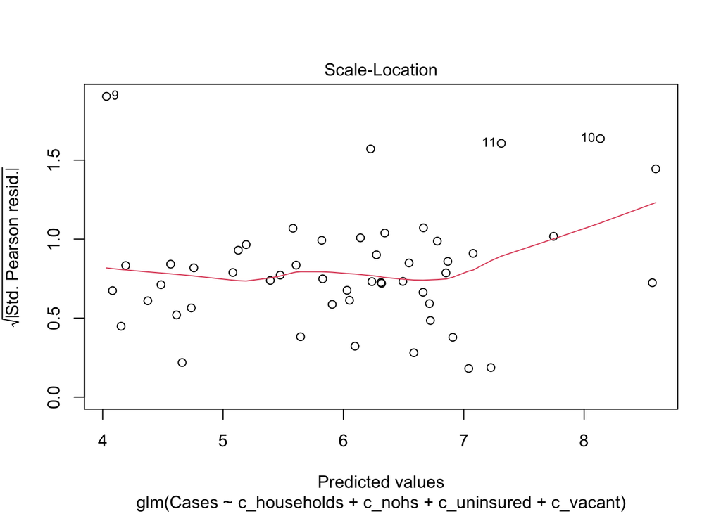

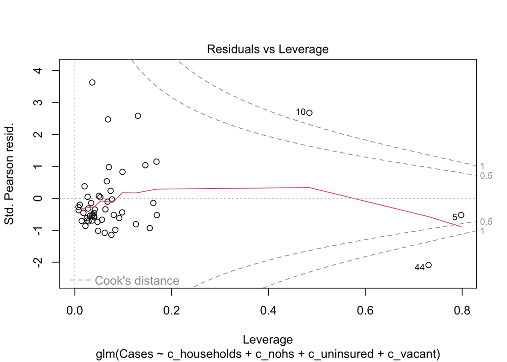

```r
plot(model6)
```

The linearity assumption may not be valid according to the fluctuating red line in the residuals vs fitted plot (answers may vary). In the Q-Q plot, the data is far away from the straight line on the right tails, which indicates that the standardized residuals are not normally distributed. The increasing red line in the scale-location plot indicates there may be model violations (here, the standardized Pearson residuals should look like constant variance). According to the rule of thumb >1 for Cook’s distance, there are two influential points which are of concern.

**15.** Compare the p-values of the predictors in the fitted model without the overdispersion parameter and the fitted model with the overdispersion parameter.

The p-values for all the predictors increased after accounting for overdispersion.

**16.** Back transform the intercept and provide an approximate 95% confidence interval, then interpret the back-transformed intercept.

```r
res <- summary(model6)

# intercept
beta0 <-  res$coefficients[1,1]
var0 <- res$coefficients[1,2]
# estimate
est <- exp(beta0)
(lower <- exp((beta0)-1.96*var0))
```

```
## [1] 11.14344
```

```r
(upper <- exp((beta0)+1.96*var0))
```

```
## [1] 14.73105
```

The back-transformed intercept is $\exp (2.55)=12.81$, with approximate 95% confidence interval (11.14, 14.73).

**17.** What is the percentage change in cases per 100k when the proportion of uninsured increases from 5 to 6?

```r
100*(exp(0.03365)-1)
```

```
## [1] 3.422257
```

When the proportion of uninsured increases from 5 to 6, the cases per 100,000 people increases 3%.

**18.** What is the percentage change in cases per 100k when the proportion of uninsured increases from 15 to 16?

```r
100*(exp(0.03365)-1)
```

```
## [1] 3.422257
```

When the proportion of uninsured increases from 15 to 16, the cases per 100,000 people increases 3%.

**19.** Now fit a log linear model assuming Gaussianity instead of Poisson using the `lm()` function (i.e., OLS). Use log `Rate.per.100000` as the response and include centered predictors `Households living below the federal poverty level`, `Population 25 years and older w/o HS diploma`, `Uninsured`, and `Vacant housing`. Assess model assumptions using `plot()`. (Comment on each of the four plots.)

```r
dat$log.Rate.per.100000 = log(dat$Rate.per.100000)
model8 = lm(log.Rate.per.100000~c_households+c_nohs+c_uninsured+c_vacant,data=dat)
summary(model8)
```

```
##
## Call:
## lm(formula = log.Rate.per.100000 ~ c_households + c_nohs + c_uninsured +
##     c_vacant, data = dat)
##
## Residuals:
##      Min       1Q   Median       3Q      Max
## -1.25660 -0.33090 -0.00322  0.29581  1.67853
##
## Coefficients:
##              Estimate Std. Error t value Pr(>|t|)
## (Intercept)   2.23632    0.07724  28.952  < 2e-16 ***
## c_households  0.05235    0.05172   1.012  0.31670
## c_nohs        0.09241    0.05225   1.769  0.08357 .
## c_uninsured   0.03344    0.02910   1.149  0.25656
## c_vacant     -0.06202    0.02231  -2.780  0.00785 **
## ---
## Signif. codes:  0 '***' 0.001 '**' 0.01 '*' 0.05 '.' 0.1 ' ' 1
##
## Residual standard error: 0.5516 on 46 degrees of freedom
## Multiple R-squared:  0.4585, Adjusted R-squared:  0.4114
## F-statistic: 9.736 on 4 and 46 DF,  p-value: 8.625e-06
```

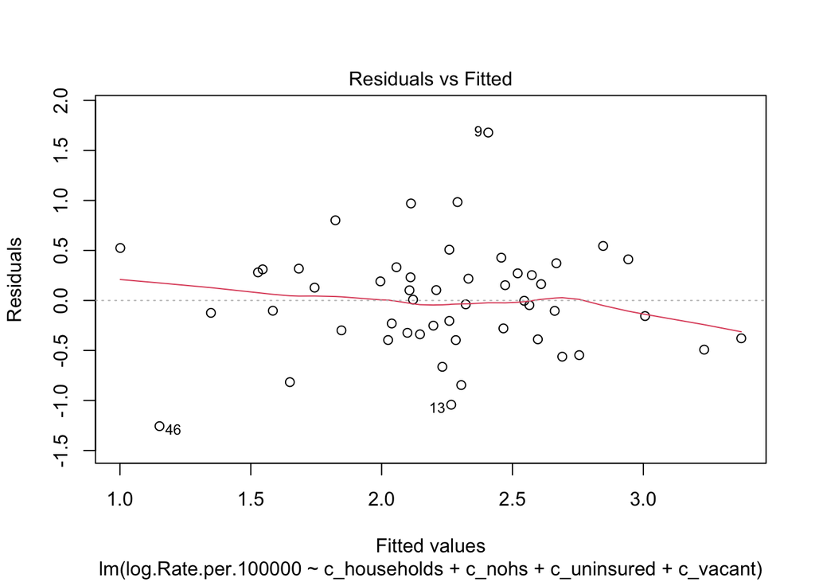

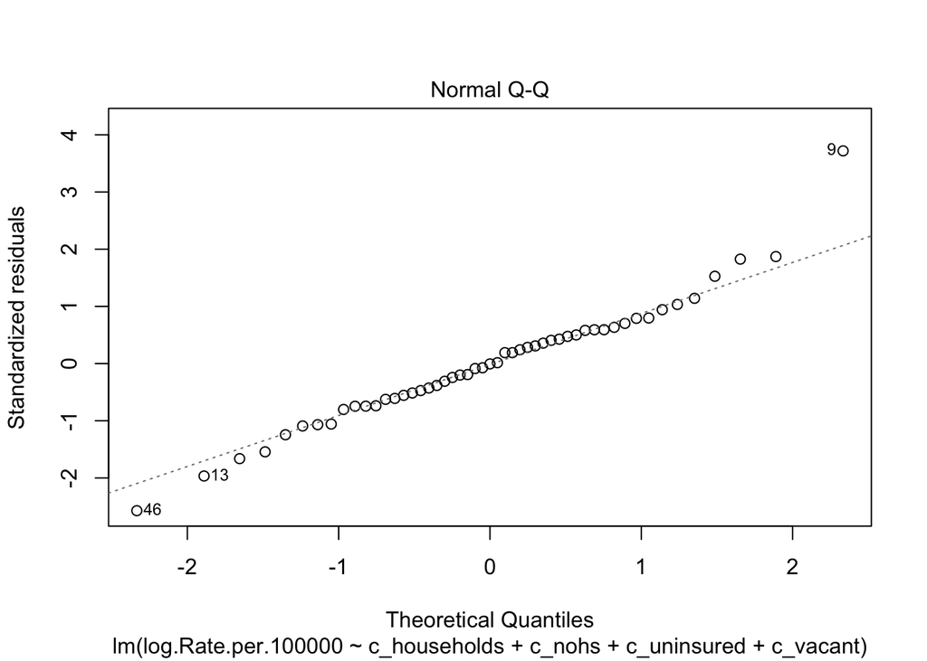

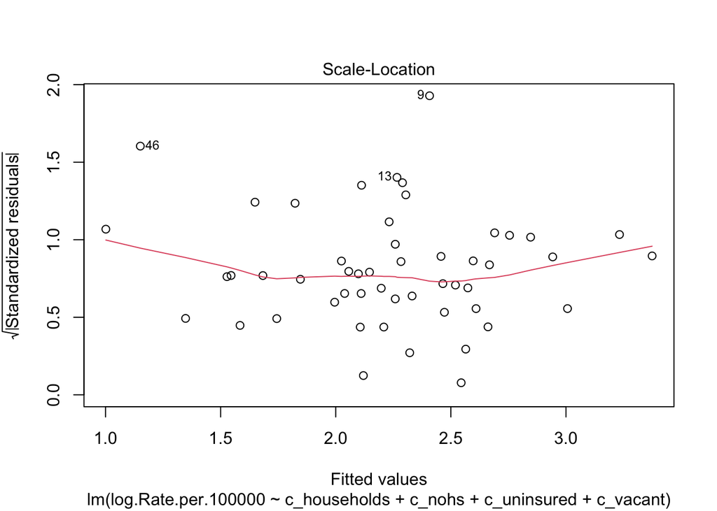

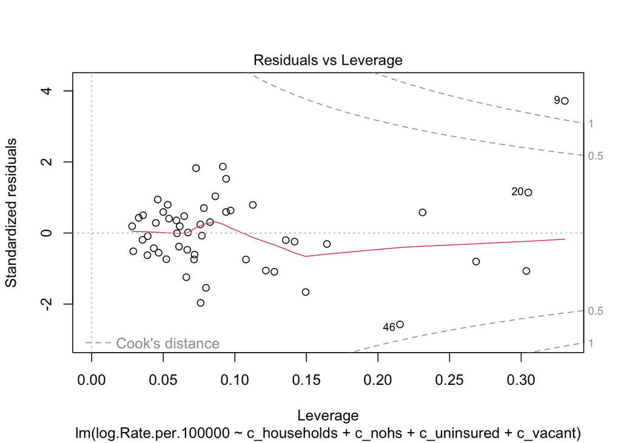

```r
plot(model8)
```

The first plot is used to check the linearity assumption and homoscedasticity. The red line is almost flat with minor fluctuations, which doesn’t indicate a severe violation of the linearity assumption.

In the Q-Q plot, the data is very close to the straight line, which indicates that the standardized residuals are approximately normally distributed.

The third plot is used to check the homoscedasticity. The red line is almost flat with minor fluctuations, which doesn’t indicate a severe violation of the homoscedasticity assumption.

According to the rule of thumb > 1 for Cook’s distance, there is one influential point which is of concern.

**20.** What is the percentage change in cases per 100k when the proportion of uninsured increases by one unit?

```r
100*(exp(0.03344)-1)
```

```
## [1] 3.40054
```

When the proportion of uninsured increases by one unit, the cases per 100,000 people increases 3.4%.

**21.** How do the coefficient estimates and p-values compare between the overdispersed Poisson model and the log transformed OLS model?

```r
summary(model6)$coefficients
```

```
##                Estimate Std. Error    t value     Pr(>|t|)
## (Intercept)  2.55040411 0.07120066 35.8199480 3.001687e-35
## c_households 0.00475001 0.04508142  0.1053651 9.165442e-01
## c_nohs       0.06239397 0.03400408  1.8348967 7.299225e-02
## c_uninsured  0.03365001 0.01901833  1.7693466 8.346523e-02
## c_vacant     0.02963076 0.02316945  1.2788717 2.073565e-01
```

```r
summary(model8)$coefficients
```

```
##                 Estimate Std. Error   t value     Pr(>|t|)
## (Intercept)   2.23632352 0.07724254 28.951969 3.563600e-31
## c_households  0.05235369 0.05171855  1.012281 3.166990e-01
## c_nohs        0.09240994 0.05224615  1.768742 8.356742e-02
## c_uninsured   0.03343687 0.02910496  1.148838 2.565618e-01
## c_vacant     -0.06202146 0.02231159 -2.779786 7.853462e-03
```

The estimates and p-values differ between the two models, with the estimates for `Vacant housing` even showing opposite directions.

# 2 Problem 2.

In this problem, we will use logistic regression to examine the factors influencing the presence of pathogens in fecal sludges in Malawi.

```r
malawi = read.csv('Malawi_Fecal_Sludge_Data_to_post.csv')
```

**1.** Write out a statistical model that uses logistic regression with response `Depth_pathogen_presence` with random effects for `Latrine_ID`, `Pathogen_Target`, and their interaction, and including `Depth`, `HH_population`, `shared_latrine`, `pit_type`, `water_source`, and `toilet_paper` as fixed effects. Let $\theta_{0i}$, $\theta_{1j}$, and $\theta_{2ij}$ denote the random effects, which we assume are independent. For factors, use the R convention reference level and include a separate coefficient for each level.

$$y_{ijk} \sim Binomial (p_{ijk})
,$$
$$logit(p_{ijk}) =
\beta_0+\theta_{0i}+\theta_{1j}+\theta_{2ij}+\beta_{Depth1}*I(x_{1ijk}=Middle)+\beta_{Depth2}*I(x_{1ijk}=Top)+\vec{x}_{i}'\vec{\beta},$$
$$\theta_{0i} \overset{iid}{\sim} N(0,
\tau^2) \quad \theta_{1j} \overset{iid}{\sim} N(0, \nu^2) \quad
\theta_{2ij}\overset{iid}{\sim} N(0, \zeta^2)$$

where $y_{ijk}$ is the presence or absence of a pathogen in the $k^{th}$ observation (or sampling depth) for latrine $i$ and pathogen target $j$; $p_{ijk} = P(y_{ijk} = 1)$; $\vec{x}_{i}$ = [`HH_population`, `shared_latrine`, `pit_type` (no slab as reference), `water_source=house` (compound as reference), `water_source=public` (compound as reference), and `toilet_paper` (paper as reference)]; $x_{1ijk}$ = `Depth` of the $k^{th}$ observation for latrine $i$ and pathogen target $j$; $\tau^2$, $\nu^2$, $\zeta^2$ are the variations between latrines, pathogen targets, and the specific combinations of pathogen targets and latrines, respectively.

**2.** What is $Var[y_{ijk} \ | \theta_{0i}, \theta_{1j}, \theta_{2ij}]$?

$Var[y_{ijk} \ | \theta_{0i}, \theta_{1j}, \theta_{2ij}] = p_{ijk}(1-p_{ijk})$

**3.** Fit the model using the default optimizer. For the random effects, use the form (1|Latrine_ID)+(1|Pathogen_Target)+(1|Latrine_ID:Pathogen_Target). Do you get any warnings? If so, what are they?

```r
library(lme4)
model2.0 = glmer(Depth_pathogen_presence~Depth+HH_population+shared_latrine+pit_type+water_source+toilet_paper+(1|Pathogen_Target)+(1|Latrine_ID)+(1|Latrine_ID:Pathogen_Target),data=malawi,family=binomial)
```

```
## Warning in checkConv(attr(opt, "derivs"), opt$par, ctrl = control$checkConv, :
## Model failed to converge with max|grad| = 0.0935926 (tol = 0.002, component 1)
```

```r
summary(model2.0)
```

```
## Generalized linear mixed model fit by maximum likelihood (Laplace
##   Approximation) [glmerMod]
##  Family: binomial  ( logit )
## Formula: Depth_pathogen_presence ~ Depth + HH_population + shared_latrine +
##     pit_type + water_source + toilet_paper + (1 | Pathogen_Target) +
##     (1 | Latrine_ID) + (1 | Latrine_ID:Pathogen_Target)
##    Data: malawi
##
##      AIC      BIC   logLik deviance df.resid
##   1443.0   1510.1   -709.5   1419.0     1968
##
## Scaled residuals:
##      Min       1Q   Median       3Q      Max
## -2.84511 -0.22792 -0.05012  0.26166  2.57976
##
## Random effects:
##  Groups                     Name        Variance Std.Dev.
##  Latrine_ID:Pathogen_Target (Intercept)  3.72648 1.9304
##  Latrine_ID                 (Intercept)  0.03641 0.1908
##  Pathogen_Target            (Intercept) 16.18449 4.0230
## Number of obs: 1980, groups:
## Latrine_ID:Pathogen_Target, 660; Latrine_ID, 33; Pathogen_Target, 20
##
## Fixed effects:
##                    Estimate Std. Error z value Pr(>|z|)
## (Intercept)        -2.81819    1.08801  -2.590  0.00959 **
## DepthMiddle         0.07644    0.19884   0.384  0.70066
## DepthTop           -0.22043    0.19914  -1.107  0.26833
## HH_population       0.17938    0.04289   4.182 2.89e-05 ***
## shared_latrine      0.22451    0.31100   0.722  0.47036
## pit_typeslab       -0.11296    0.38766  -0.291  0.77075
## water_sourcehouse  -1.25192    0.40279  -3.108  0.00188 **
## water_sourcepublic  0.77511    0.36175   2.143  0.03214 *
## toilet_paperWater   0.60641    0.42595   1.424  0.15454
## ---
## Signif. codes:  0 '***' 0.001 '**' 0.01 '*' 0.05 '.' 0.1 ' ' 1
##
## Correlation of Fixed Effects:
##             (Intr) DpthMd DpthTp HH_ppl shrd_l pt_typ wtr_srch wtr_srcp
## DepthMiddle -0.095
## DepthTop    -0.081  0.498
## HH_populatn -0.348  0.006 -0.017
## shared_ltrn -0.083  0.001 -0.002 -0.245
## pit_typeslb -0.310  0.000  0.001  0.117 -0.150
## water_srchs  0.024 -0.004  0.013 -0.124  0.111 -0.122
## wtr_srcpblc -0.247  0.003 -0.008  0.349 -0.090  0.194  0.080
## tolt_pprWtr -0.067  0.002 -0.007  0.182 -0.131 -0.047 -0.421    0.169
## optimizer (Nelder_Mead) convergence code: 0 (OK)
## Model failed to converge with max|grad| = 0.0935926 (tol = 0.002, component 1)
```

There is a failing to converge warning ‘Model failed to converge with max|grad| = 0.0935926 (tol = 0.002, component 1)’.

**4.** Fit all available optimizers using `allFit()`. Adapt this code: `lapply(allfits,function(x) x@optinfo$conv$lme4$messages)`. Did any algorithms converge?

```r
library(dfoptim)
library(optimx)
allfits = allFit(model2.0)
```

```
## bobyqa : [OK]
## Nelder_Mead :
```

```
## Warning in checkConv(attr(opt, "derivs"), opt$par, ctrl = control$checkConv, :
## unable to evaluate scaled gradient
```

```
## [OK]
## nlminbwrap : [OK]
## nmkbw :
```

```
## [OK]
## optimx.L-BFGS-B :
```

```
## [OK]
## nloptwrap.NLOPT_LN_NELDERMEAD :
```

```
## [OK]
## nloptwrap.NLOPT_LN_BOBYQA :
```

```
## [OK]
```

```r
lapply(allfits,function(x) x@optinfo$conv$lme4$messages)
```

```
## $bobyqa
## NULL
##
## $Nelder_Mead
## [1] "unable to evaluate scaled gradient"
## [2] "Model failed to converge: degenerate  Hessian with 1 negative eigenvalues"
##
## $nlminbwrap
## NULL
##
## $nmkbw
## [1] "Model failed to converge with max|grad| = 0.00248966 (tol = 0.002, component 1)"
##
## $`optimx.L-BFGS-B`
## [1] "Model failed to converge with max|grad| = 0.00298369 (tol = 0.002, component 1)"
##
## $nloptwrap.NLOPT_LN_NELDERMEAD
## [1] "unable to evaluate scaled gradient"
## [2] "Model failed to converge: degenerate  Hessian with 1 negative eigenvalues"
##
## $nloptwrap.NLOPT_LN_BOBYQA
## [1] "Model failed to converge with max|grad| = 0.0026471 (tol = 0.002, component 1)"
```

According to the results above, optimizers “bobyqa” and “nlminbwrap” converge.

**5.** Check whether the results differ greatly across optimizers. Use `lapply(allfits,print)`. In the interest of time, restrict your comments to comments on how the variance components compare for different optimizers.

```r
lapply(allfits,print)
```

```
## Generalized linear mixed model fit by maximum likelihood (Laplace
##   Approximation) [glmerMod]
##  Family: binomial  ( logit )
## Formula: Depth_pathogen_presence ~ Depth + HH_population + shared_latrine +
##     pit_type + water_source + toilet_paper + (1 | Pathogen_Target) +
##     (1 | Latrine_ID) + (1 | Latrine_ID:Pathogen_Target)
##    Data: malawi
##      AIC      BIC   logLik deviance df.resid
##  1443.00  1510.09  -709.50  1419.00     1968
## Random effects:
##  Groups                     Name        Std.Dev.
##  Latrine_ID:Pathogen_Target (Intercept) 1.9354
##  Latrine_ID                 (Intercept) 0.1942
##  Pathogen_Target            (Intercept) 4.0702
## Number of obs: 1980, groups:
## Latrine_ID:Pathogen_Target, 660; Latrine_ID, 33; Pathogen_Target, 20
## Fixed Effects:
##        (Intercept)         DepthMiddle            DepthTop       HH_population
##           -2.82812             0.07925            -0.21786             0.17997
##     shared_latrine        pit_typeslab   water_sourcehouse  water_sourcepublic
##            0.22504            -0.11119            -1.25232             0.77878
##  toilet_paperWater
##            0.60689
## Generalized linear mixed model fit by maximum likelihood (Laplace
##   Approximation) [glmerMod]
##  Family: binomial  ( logit )
## Formula: Depth_pathogen_presence ~ Depth + HH_population + shared_latrine +
##     pit_type + water_source + toilet_paper + (1 | Pathogen_Target) +
##     (1 | Latrine_ID) + (1 | Latrine_ID:Pathogen_Target)
##    Data: malawi
##       AIC       BIC    logLik  deviance  df.resid
## 1443.0701 1510.1603 -709.5351 1419.0701      1968
## Random effects:
##  Groups                     Name        Std.Dev.
##  Latrine_ID:Pathogen_Target (Intercept) 1.946796
##  Latrine_ID                 (Intercept) 0.003927
##  Pathogen_Target            (Intercept) 4.062468
## Number of obs: 1980, groups:
## Latrine_ID:Pathogen_Target, 660; Latrine_ID, 33; Pathogen_Target, 20
## Fixed Effects:
```

[output cut: 111 more lines]

```
## Random effects:
##  Groups                     Name        Std.Dev.
##  Latrine_ID:Pathogen_Target (Intercept) 1.9355
##  Latrine_ID                 (Intercept) 0.1941
##  Pathogen_Target            (Intercept) 4.0707
## Number of obs: 1980, groups:
## Latrine_ID:Pathogen_Target, 660; Latrine_ID, 33; Pathogen_Target, 20
## Fixed Effects:
##        (Intercept)         DepthMiddle            DepthTop       HH_population
##           -2.82875             0.07925            -0.21789             0.17996
##     shared_latrine        pit_typeslab   water_sourcehouse  water_sourcepublic
##            0.22563            -0.11114            -1.25240             0.77871
##  toilet_paperWater
##            0.60705
## optimizer (nloptwrap) convergence code: 0 (OK) ; 0 optimizer warnings; 1 lme4 warnings
```

```
## $bobyqa
## Generalized linear mixed model fit by maximum likelihood (Laplace
##   Approximation) [glmerMod]
##  Family: binomial  ( logit )
## Formula: Depth_pathogen_presence ~ Depth + HH_population + shared_latrine +
##     pit_type + water_source + toilet_paper + (1 | Pathogen_Target) +
##     (1 | Latrine_ID) + (1 | Latrine_ID:Pathogen_Target)
##    Data: malawi
##      AIC      BIC   logLik deviance df.resid
##  1443.00  1510.09  -709.50  1419.00     1968
## Random effects:
##  Groups                     Name        Std.Dev.
##  Latrine_ID:Pathogen_Target (Intercept) 1.9354
##  Latrine_ID                 (Intercept) 0.1942
##  Pathogen_Target            (Intercept) 4.0702
## Number of obs: 1980, groups:
## Latrine_ID:Pathogen_Target, 660; Latrine_ID, 33; Pathogen_Target, 20
## Fixed Effects:
##        (Intercept)         DepthMiddle            DepthTop       HH_population
##           -2.82812             0.07925            -0.21786             0.17997
##     shared_latrine        pit_typeslab   water_sourcehouse  water_sourcepublic
##            0.22504            -0.11119            -1.25232             0.77878
##  toilet_paperWater
##            0.60689
##
## $Nelder_Mead
## Generalized linear mixed model fit by maximum likelihood (Laplace
##   Approximation) [glmerMod]
##  Family: binomial  ( logit )
## Formula: Depth_pathogen_presence ~ Depth + HH_population + shared_latrine +
##     pit_type + water_source + toilet_paper + (1 | Pathogen_Target) +
##     (1 | Latrine_ID) + (1 | Latrine_ID:Pathogen_Target)
##    Data: malawi
##       AIC       BIC    logLik  deviance  df.resid
## 1443.0701 1510.1603 -709.5351 1419.0701      1968
## Random effects:
##  Groups                     Name        Std.Dev.
##  Latrine_ID:Pathogen_Target (Intercept) 1.946796
##  Latrine_ID                 (Intercept) 0.003927
##  Pathogen_Target            (Intercept) 4.062468
```

[output cut: 124 more lines]

```
## Random effects:
##  Groups                     Name        Std.Dev.
##  Latrine_ID:Pathogen_Target (Intercept) 1.9355
##  Latrine_ID                 (Intercept) 0.1941
##  Pathogen_Target            (Intercept) 4.0707
## Number of obs: 1980, groups:
## Latrine_ID:Pathogen_Target, 660; Latrine_ID, 33; Pathogen_Target, 20
## Fixed Effects:
##        (Intercept)         DepthMiddle            DepthTop       HH_population
##           -2.82875             0.07925            -0.21789             0.17996
##     shared_latrine        pit_typeslab   water_sourcehouse  water_sourcepublic
##            0.22563            -0.11114            -1.25240             0.77871
##  toilet_paperWater
##            0.60705
## optimizer (nloptwrap) convergence code: 0 (OK) ; 0 optimizer warnings; 1 lme4 warnings
```

The estimated variance components for `Pathogen_Target` and the interaction term exhibit consistency across various optimization algorithms while there is notable variability in the estimated variance component for `Latrine_ID`.

**6.** Extract the bobyqa results and report the summary. (Hint: If `allfits` is the output form `allFit`, use `model.boby=allfits[['bobyqa']])`. For variables that have $p<0.05$, state the Null hypothesis and your conclusion.

```r
model.boby = allfits[['bobyqa']]
summary(model.boby)
```

```
## Generalized linear mixed model fit by maximum likelihood (Laplace
##   Approximation) [glmerMod]
##  Family: binomial  ( logit )
## Formula: Depth_pathogen_presence ~ Depth + HH_population + shared_latrine +
##     pit_type + water_source + toilet_paper + (1 | Pathogen_Target) +
##     (1 | Latrine_ID) + (1 | Latrine_ID:Pathogen_Target)
##    Data: malawi
## Control: ctrl
##
##      AIC      BIC   logLik deviance df.resid
##   1443.0   1510.1   -709.5   1419.0     1968
##
## Scaled residuals:
##      Min       1Q   Median       3Q      Max
## -2.84132 -0.22768 -0.04961  0.26147  2.57590
##
## Random effects:
##  Groups                     Name        Variance Std.Dev.
##  Latrine_ID:Pathogen_Target (Intercept)  3.74588 1.9354
##  Latrine_ID                 (Intercept)  0.03771 0.1942
##  Pathogen_Target            (Intercept) 16.56683 4.0702
## Number of obs: 1980, groups:
## Latrine_ID:Pathogen_Target, 660; Latrine_ID, 33; Pathogen_Target, 20
##
## Fixed effects:
##                    Estimate Std. Error z value Pr(>|z|)
## (Intercept)        -2.82812    1.09834  -2.575  0.01003 *
## DepthMiddle         0.07925    0.19900   0.398  0.69044
## DepthTop           -0.21786    0.19929  -1.093  0.27431
## HH_population       0.17997    0.04304   4.181  2.9e-05 ***
## shared_latrine      0.22504    0.31198   0.721  0.47070
## pit_typeslab       -0.11119    0.38890  -0.286  0.77494
## water_sourcehouse  -1.25232    0.40400  -3.100  0.00194 **
## water_sourcepublic  0.77878    0.36294   2.146  0.03189 *
## toilet_paperWater   0.60689    0.42727   1.420  0.15550
## ---
## Signif. codes:  0 '***' 0.001 '**' 0.01 '*' 0.05 '.' 0.1 ' ' 1
##
## Correlation of Fixed Effects:
##             (Intr) DpthMd DpthTp HH_ppl shrd_l pt_typ wtr_srch wtr_srcp
## DepthMiddle -0.094
## DepthTop    -0.080  0.498
## HH_populatn -0.346  0.006 -0.017
## shared_ltrn -0.082  0.001 -0.002 -0.245
## pit_typeslb -0.308  0.000  0.001  0.117 -0.150
## water_srchs  0.024 -0.005  0.012 -0.124  0.111 -0.123
## wtr_srcpblc -0.246  0.003 -0.008  0.349 -0.090  0.194  0.079
## tolt_pprWtr -0.067  0.002 -0.007  0.182 -0.131 -0.047 -0.421    0.169
```

```r
#should be equivalent:
model2.4 = glmer(Depth_pathogen_presence~Depth+HH_population+shared_latrine+pit_type+water_source+toilet_paper+(1|Pathogen_Target)+(1|Latrine_ID)+(1|Latrine_ID:Pathogen_Target),data=malawi,family=binomial,glmerControl(optimizer='bobyqa'))
summary(model2.4)
```

```
## Generalized linear mixed model fit by maximum likelihood (Laplace
##   Approximation) [glmerMod]
##  Family: binomial  ( logit )
## Formula: Depth_pathogen_presence ~ Depth + HH_population + shared_latrine +
##     pit_type + water_source + toilet_paper + (1 | Pathogen_Target) +
##     (1 | Latrine_ID) + (1 | Latrine_ID:Pathogen_Target)
##    Data: malawi
## Control: glmerControl(optimizer = "bobyqa")
##
##      AIC      BIC   logLik deviance df.resid
##   1443.0   1510.1   -709.5   1419.0     1968
##
## Scaled residuals:
##      Min       1Q   Median       3Q      Max
## -2.84132 -0.22768 -0.04961  0.26147  2.57590
##
## Random effects:
##  Groups                     Name        Variance Std.Dev.
##  Latrine_ID:Pathogen_Target (Intercept)  3.74588 1.9354
##  Latrine_ID                 (Intercept)  0.03771 0.1942
##  Pathogen_Target            (Intercept) 16.56683 4.0702
## Number of obs: 1980, groups:
## Latrine_ID:Pathogen_Target, 660; Latrine_ID, 33; Pathogen_Target, 20
##
## Fixed effects:
##                    Estimate Std. Error z value Pr(>|z|)
## (Intercept)        -2.82812    1.09834  -2.575  0.01003 *
## DepthMiddle         0.07925    0.19900   0.398  0.69044
## DepthTop           -0.21786    0.19929  -1.093  0.27431
## HH_population       0.17997    0.04304   4.181  2.9e-05 ***
## shared_latrine      0.22504    0.31198   0.721  0.47070
## pit_typeslab       -0.11119    0.38890  -0.286  0.77494
## water_sourcehouse  -1.25232    0.40400  -3.100  0.00194 **
## water_sourcepublic  0.77878    0.36294   2.146  0.03189 *
## toilet_paperWater   0.60689    0.42727   1.420  0.15550
## ---
## Signif. codes:  0 '***' 0.001 '**' 0.01 '*' 0.05 '.' 0.1 ' ' 1
##
## Correlation of Fixed Effects:
##             (Intr) DpthMd DpthTp HH_ppl shrd_l pt_typ wtr_srch wtr_srcp
## DepthMiddle -0.094
## DepthTop    -0.080  0.498
## HH_populatn -0.346  0.006 -0.017
## shared_ltrn -0.082  0.001 -0.002 -0.245
## pit_typeslb -0.308  0.000  0.001  0.117 -0.150
## water_srchs  0.024 -0.005  0.012 -0.124  0.111 -0.123
## wtr_srcpblc -0.246  0.003 -0.008  0.349 -0.090  0.194  0.079
## tolt_pprWtr -0.067  0.002 -0.007  0.182 -0.131 -0.047 -0.421    0.169
```

After accounting for correlations among observations within the same latrine, the same pathogen target, and the same combination of latrine and pathogen target,

1. Intercept:
   - Null hypothesis: The baseline probability of the presence of pathogens is 0.5.
   - Conclusion: Since p-value = 0.01002 < 0.05, we reject the null hypothesis and conclude that the baseline probability of the presence of pathogens is significantly different from 0.5.
2. HH_population:
   - Null hypothesis: The coefficient of `HH_population` is 0. Or, `HH_population` does not significantly influence the presence of pathogens.
   - Conclusion: Since p-value = 2.9e-05 < 0.05, we reject the null hypothesis and conclude that the coefficient of `HH_population` significantly differs from zero. Or, `HH_population` significantly influences the presence of pathogens.
3. water_sourcehouse:
   - Null hypothesis: the presence of pathogens in a latrine with a house water source does not significantly differ from that in a latrine with a compound water source.
   - Conclusion: Since p-value = 0.00194 < 0.05, we reject the null hypothesis and conclude that the probability of the presence of pathogens in a latrine with a household water source is significantly different from that in a latrine with a compound water source.
4. water_sourcepublic:
   - Null hypothesis: the presence of pathogens in a latrine with a public water source does not significantly differ from that in a latrine with a compound water source.
   - Conclusion: Since p-value = 0.03189 < 0.05, we reject the null hypothesis and conclude that the probability of the presence of pathogens in a latrine with a public water source is significantly different from that in a latrine with a compound water source.

**7.** Interpret the coefficient of `DepthTop` and provide a 95% confidence interval.

```r
coefs = summary(allfits[['bobyqa']])$coefficients
est = coefs['DepthTop', 'Estimate']
se = coefs['DepthTop', 'Std. Error']
est
```

```
## [1] -0.2178571
```

```r
est - 1.96 * se
```

```
## [1] -0.6084587
```

```r
est + 1.96 * se
```

```
## [1] 0.1727445
```

After controlling for all other variables, and the correlations among observations within the same latrine, the same pathogen target, and the same combination of latrine and target, the log odds ratio of having pathogens for a latrine with Depth = Top versus Depth = bottom is -0.2178571, with 95% confidence interval (-0.6084587, 0.1727445).

**8.** What is the odds ratio for a pathogen in a latrine with a public water source versus a compound water source, with 95% confidence interval?

```r
est = coefs['water_sourcepublic', 'Estimate']
se = coefs['water_sourcepublic', 'Std. Error']
exp(est)
```

```
## [1] 2.178809
```

```r
exp(est - 1.96 * se)
```

```
## [1] 1.069739
```

```r
exp(est + 1.96 * se)
```

```
## [1] 4.437728
```

The odds ratio is 2.1788091, with 95% confidence interval (1.0697387, 4.4377276).

**9.** What is the probability of pathogen presence in a household with 10 people with a public water source, all other variables set to the baseline?

```r
pred = coefs['(Intercept)', 'Estimate'] +
  10 * coefs['HH_population', 'Estimate'] +
  coefs['water_sourcepublic', 'Estimate']
p = 1/(1 + exp(-1 * pred))
p
```

```
## [1] 0.4379059
```

The probability is 0.4379059.